# 05_analysis

## Library

```r
library("tidyverse")
library("broom")
library("ggthemes")
library("ggrepel")
library("ggplot2")
library("patchwork")
library(graphics)
source(here("R/99_functions.R"))
```

## Load data

Loading in the data from 03_augment for the volcano plots.

```r
df_volcano_clp_hsc <- read_tsv(file = str_c(here("data"), "df_volcano_clp_hsc.tsv.gz", sep = "/"))

df_volcano_cmp_hsc <- read_tsv(file = str_c(here("data"), "df_volcano_cmp_hsc.tsv.gz", sep = "/"))

df_volcano_gmp_cmp <- read_tsv(file = str_c(here("data"), "df_volcano_gmp_cmp.tsv.gz", sep = "/"))

df_volcano_mep_cmp <- read_tsv(file = str_c(here("data"), "df_volcano_mep_cmp.tsv.gz", sep = "/"))
```

## Volcano plots

P05213 is tubulin, tubulin is the major constituent of microtubules, a cylinder consisting of laterally associated linear protofilaments composed of alpha- and beta-tubulin heterodimers.

We will look at the development from HSC to CLP and from HSC to CMP.

And then from CMP to MEP and from CMP to GMP. Because that is the order in which the cells develop.

## Creating and saving volcano plots

The volcano plot tibbles created in 03_augment are used to create volcano plots with ggplot. The plots are saved to variables which are used to render image.png files used in the presentation

### Comparing clp to hsc

```r
plot_clp_hsc <- df_volcano_clp_hsc |>
  mutate(label = case_when(expression == "overexpressed" & fold_log2 > 2 ~ protein_groups,.default = "")) |>
  ggplot(aes(x = fold_log2, y = desc(log10(q_val)), color = expression))+
  geom_point(size=0.5, alpha = 0.5)+
  theme_classic()+
  geom_text_repel(aes(label = label), size = 3)+
  labs(title = "Expression of CLP relative to HSC",
       x = "Log2fold-change",
       y = "-log10(q)",
       caption = "proteomics data")+
  theme(legend.position = "bottom",
        legend.title = element_blank(),
        legend.text = element_text(size = 12))+
  guides(color = guide_legend(override.aes = list(shape = 19, size = 5, alpha = 1)))+
  #The horizontal line that indicates significance
#  geom_hline(yintercept = 2)+
  scale_color_manual(values = c("overexpressed" = "#D55E00", "underexpressed" = "#0072B2", "not_significant" = "gray"))
```

### Comparing cmp to hsc

```r
plot_cmp_hsc <- df_volcano_cmp_hsc|>
  mutate(label = case_when(expression == "overexpressed" & fold_log2 > 2 ~ protein_groups,.default = "")) |>
  ggplot(aes(x = fold_log2, y = desc(log10(q_val)), color = expression))+
  geom_point(size=0.5, alpha = 0.5)+
  theme_classic()+
  geom_text_repel(aes(label = label), size = 3)+
  labs(title = "Expression of CMP relative to HSC",
       x = "Log2fold-change",
       y = "-log10(q)",
       caption = "proteomics data")+
  theme(legend.position = "bottom",
        legend.title = element_blank(),
        legend.text = element_text(size = 12))+
  guides(color = guide_legend(override.aes = list(shape = 19, size = 5, alpha = 1)))+
  #The horizontal line that indicates significance
#  geom_hline(yintercept = 2)+
  scale_color_manual(values = c("overexpressed" = "#D55E00", "underexpressed" = "#0072B2", "not_significant" = "gray"))
```

### Comparing mep to cmp

```r
plot_mep_cmp <- df_volcano_mep_cmp |>
  mutate(label = case_when(expression == "overexpressed" & fold_log2 > 2 ~ protein_groups,.default = "")) |> # creates a label if it is overexpressed
  ggplot(aes(x = fold_log2, y = desc(log10(q_val)), color = expression))+
  geom_point(size=0.5, alpha = 0.5)+
  theme_classic()+
  geom_text_repel(aes(label = label), size = 3)+
  labs(title = "Expression of MEP relative to CMP",
       x = "Log2fold-change",
       y = "-log10(q)",
       caption = "proteomics data")+
  theme(legend.position = "bottom",
        legend.title = element_blank(),
        legend.text = element_text(size = 12))+
  guides(color = guide_legend(override.aes = list(shape = 19, size = 5, alpha = 1)))+
  #The horizontal line that indicates significance
#  geom_hline(yintercept = 2)+
scale_color_manual(values = c("overexpressed" = "#D55E00", "underexpressed" = "#0072B2", "not_significant" = "gray"))
```

### Comparing cmp to gmp

```r
plot_gmp_cmp <- df_volcano_gmp_cmp |>
  mutate(label = case_when(expression == "overexpressed" & fold_log2 > 2 ~ protein_groups,.default = "")) |>
  ggplot(aes(x = fold_log2, y = desc(log10(q_val)), color = expression))+
  geom_point(size=0.5, alpha = 0.5)+
  theme_classic()+
  geom_text_repel(aes(label = label), size = 3)+
  labs(title = "Expression of GMP relative to CMP",
       x = "Log2fold-change",
       y = "-log10(q)",
       caption = "proteomics data")+
  theme(legend.position = "bottom",
        legend.title = element_blank(),
        legend.text = element_text(size = 12))+
  guides(color = guide_legend(override.aes = list(shape = 19, size = 5, alpha = 1)))+
  #The horizontal line that indicates significance
#  geom_hline(yintercept = 2)+
  scale_color_manual(values = c("overexpressed" = "#D55E00",
                                "underexpressed" = "#0072B2",
                                "not_significant" = "gray"))
```

### Rendering the plots as image.png for the quarto_presentation

```r
#Due to an error occuring when saving ggplot directly in the pipeline of the latest plot which apparently is caused by a recent edit in ggplot2-3.3.4 the saving of plots is done separately.

# save hsc_clp
ggsave(plot = plot_clp_hsc,
       filename = "hsc_clp_volcano_plot.png",
       width = 20, height = 10, units = "cm",
       path = here("results"))

# save hsc_cmp
ggsave(plot = plot_cmp_hsc,
       filename = "hsc_cmp_volcano_plot.png",
       width = 20, height = 10, units = "cm",
       path = here("results"))

# save cmp_mep
ggsave(plot = plot_mep_cmp,
       filename = "cmp_mep_volcano_plot.png",
       width = 20, height = 10, units = "cm",
       path = here("results"))

# save gmp_cmp
ggsave(plot = plot_gmp_cmp,
       filename = "cmp_gmp_volcano_plot.png",
       width = 20, height = 10, units = "cm",
       path = here("results"))
```

A future direction for the project would be to assign all the protein groups categories based on their functionality. It would for instance be interesting to see which are the proteins that are overexpressed in the different cell types, but since there are so many of them it does not make sense to label all of them. We might for instance label the proteins that have a 2logfold change above 2, which means they are overexpressed by 400%.

## Showing the volcano plots

### CLP compared to HSC

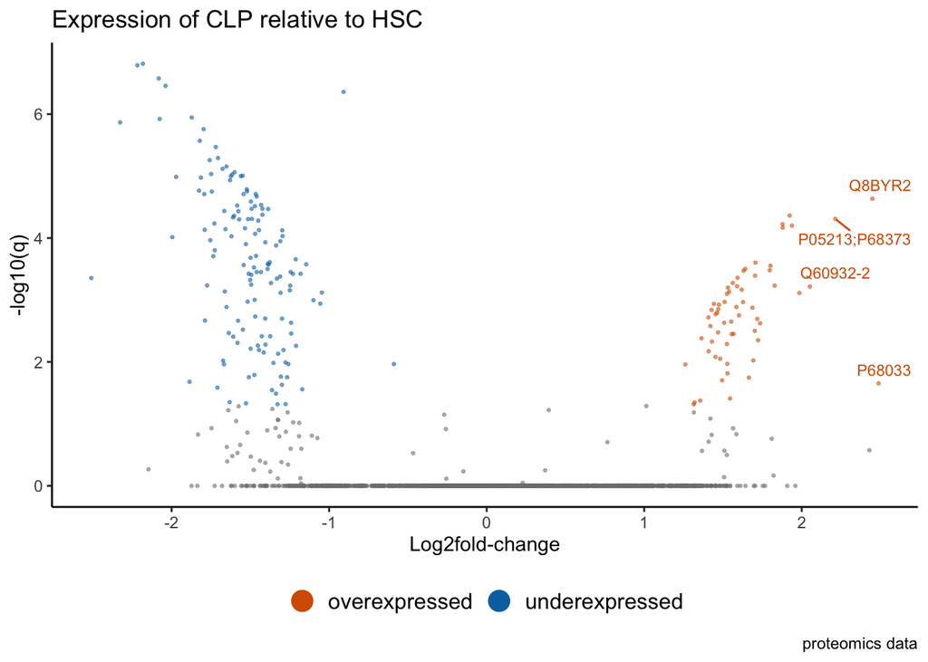

```r
plot_clp_hsc
```

### CMP compared to HSC

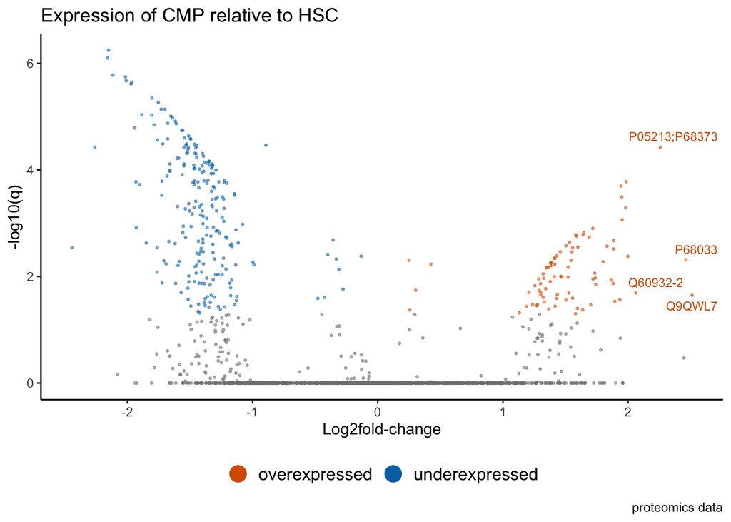

```r
plot_cmp_hsc
```

### GMP compared to CMP

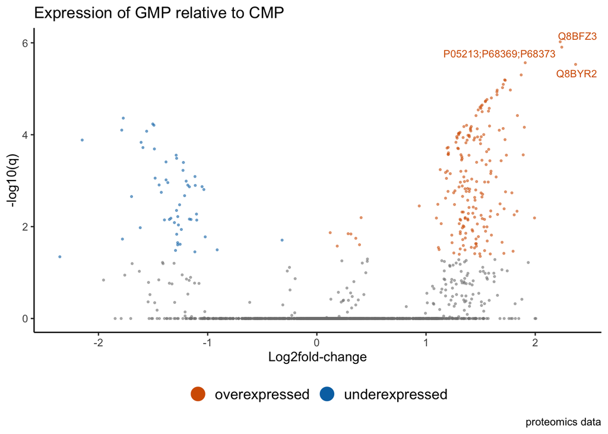

```r
plot_gmp_cmp
```

### MEP compared to CMP

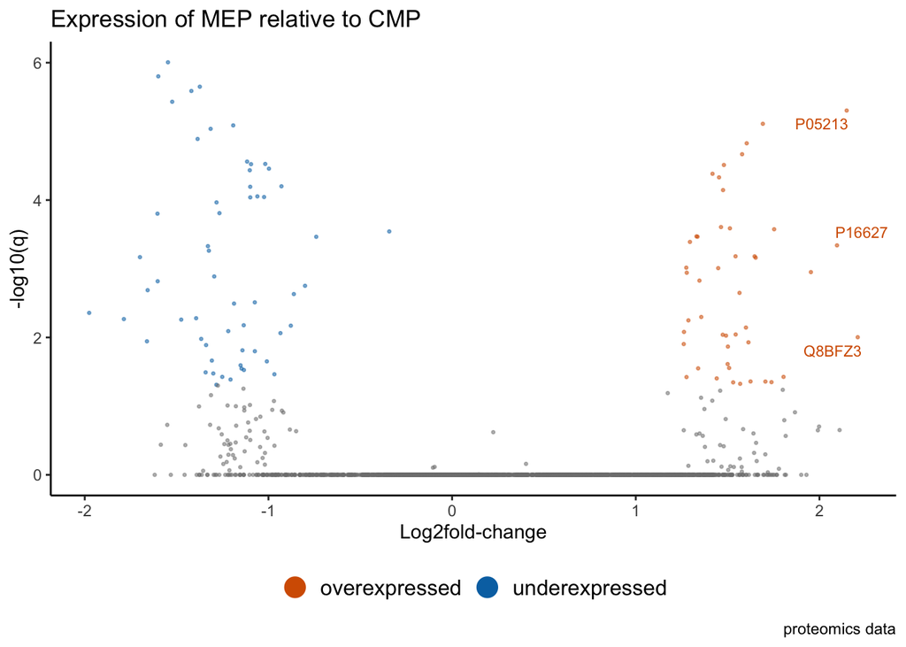

```r
plot_mep_cmp
```

Lets have a look at hsc to cmp.

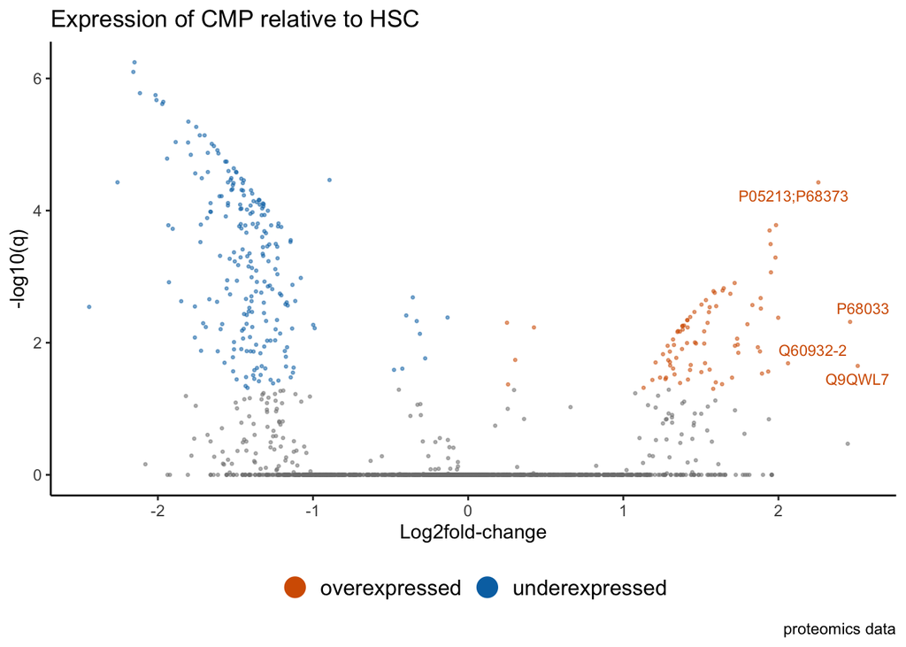

```r
# loading the plot from variable
plot_cmp_hsc
```

P68033 is an actin, actins are highly conserved proteins that are involved in various types of cell motility and are ubiquitously expressed in all eukaryotic cells.

P05213 is tubulin, tubulin is the major constituent of microtubules, a cylinder consisting of laterally associated linear protofilaments composed of alpha- and beta-tubulin heterodimers.